# Analyse the WeRateDogs twitter data

We have gathered, assessed and cleaned the data for WeRateDogs twitter account. The timeline for data gathered is for before August 1st, 2017. WeRateDogs are 'Your only source for professional dog ratings', their words not mine. :) They have a fun rating system where the numerator is usually more than the denominator and the denominator is mostly 10. Using their twitter data we will be analysing whether some dog stages are more popular than others or whether some dog breeds are getting higher ratings, do dogs with higher ratings also get more retweets and likes. We will also find the tweets with the highest ratings, retweets or likes.

[figure not shown]

Above is a doggo realizing that you can stand in a pool. With a rating of 1.3 (13/10) this doggo is really popular with maximum retweets and likes.

```python
# Import libraries
import pandas as pd
import numpy as np
import requests
import os
import re
import seaborn as sns
import tweepy
from tweepy import OAuthHandler
import json
from timeit import default_timer as timer
import matplotlib.pyplot as plt
import matplotlib.cm as cm
% matplotlib inline
```

```python
#load the dataset
twitter_data_enhanced=pd.read_csv('twitter_archive_master.csv')
```

### Insight 1: Relation between breed and rating_standardized

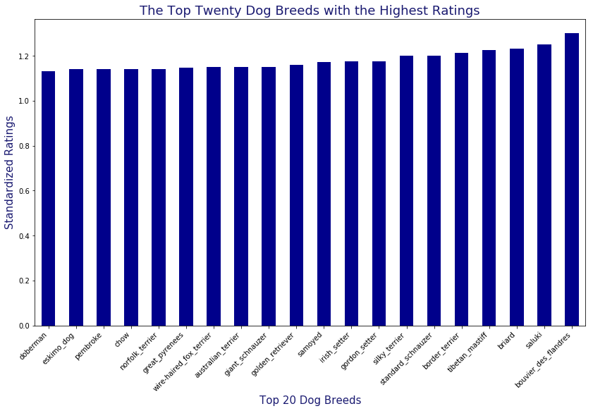

```python
#find the index of rows which have outliers for rating_standardized column
twitter_data_enhanced.query('rating_standardized > 40').index
#drop rows with outliers as it will lead to incorrect analysis of the relationship between variables
df=twitter_data_enhanced.drop([975,1593],axis=0)
#find the top 20 breeds with highest ratings
df1=df.groupby('dog_breed').rating_standardized.mean().sort_values()
#plot bar graph
plt.subplots(figsize=(14, 8))
df1.tail(20).plot(kind='bar',color='darkblue',width=0.5);
#rotate x-axis label
plt.setp(plt.gca().get_xticklabels(), rotation=45, horizontalalignment='right') #Source: https://benalexkeen.com/bar-charts-in-matplotlib/
#set chart titles and labels
plt.title('The Top Twenty Dog Breeds with the Highest Ratings',fontsize=18,color='#191970')
plt.xlabel('Top 20 Dog Breeds',fontsize=15,color='#191970')
plt.ylabel('Standardized Ratings',fontsize=15,color='#191970');
```

> We can see that the top 20 dog breeds which have the highest average ratings are:
> - bouvier_des_flandres
> - saluki
> - briard
> - tibetan_mastiff
> - border_terrier
> - standard_schnauzer
> - silky_terrier
> - gordon_setter
> - irish_setter
> - samoyed
> - golden_retriever
> - giant_schnauzer
> - australian_terrier
> - wire-haired_fox_terrier
> - great_pyrenees
> - norfolk_terrier
> - chow
> - pembroke
> - eskimo_dog
> - doberman

### Insights 2: Dog Breeds with highest favourite counts

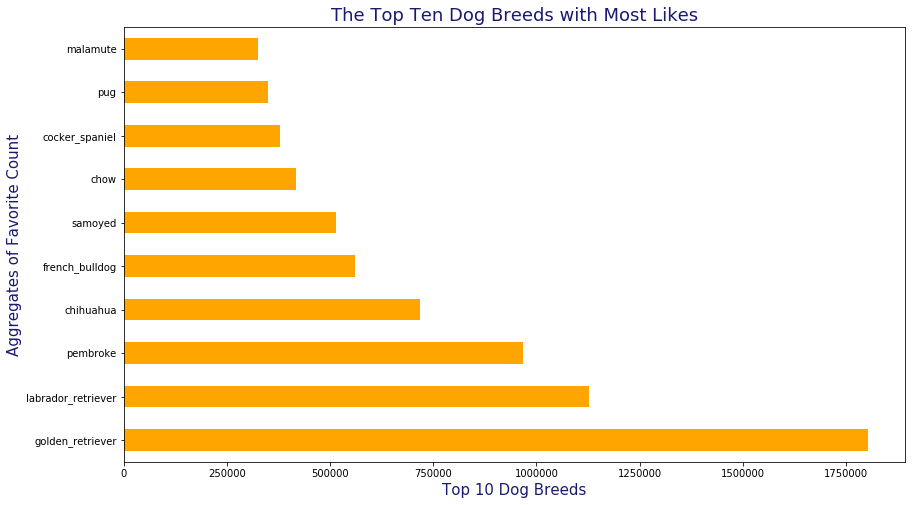

```python
#find the top 10 breeds with highest likes(aggregated values)
df2=twitter_data_enhanced.groupby('dog_breed').favorite_count.sum().sort_values()
plt.subplots(figsize=(14, 8))
df2.tail(10).plot(kind='barh',color='orange',width=0.5);
#invert y-axis label
plt.gca().invert_yaxis()
#set chart titles and labels
plt.title('The Top Ten Dog Breeds with Most Likes',fontsize=18,color='#191970')
plt.xlabel('Top 10 Dog Breeds',fontsize=15,color='#191970')
plt.ylabel('Aggregates of Favorite Count',fontsize=15,color='#191970');
```

We have calculated the aggregate values for favorite count for each breed of dogs. In our analysis we can see that golden retriever has the maximum likes followed by labrador retriever

### Insight 3: Which dog stages have higher retweet counts

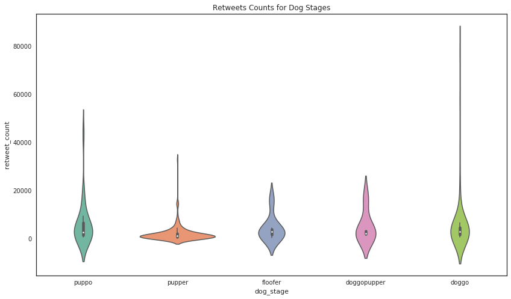

```python
#plot violinplot to see the relation between dog stage and retweet count
plt.figure(figsize = (14, 8))
sns.set(style="white")
plt.title('Retweets Counts for Dog Stages')
ax=sns.violinplot(data=twitter_data_enhanced, x='dog_stage', y='retweet_count',linewidth=1.5,palette="Set2");
```

> In our analysis we can see that the value count for pupper is highest but the average retweet_count is for doggo. From our violinplot visualization we can see that the pupper has highest density around 0 and hence has the lowest average retweet count. Doggo stage has the maximum outliers, this means that some of the tweets have very high value of retweets. Hence we can say that doggo is the more popular dog stage as the shape of the graph shows that the frequency for retweet_count is spread over a large range of values.

### Insight 4: Relationship between retweet_count and favorite_count

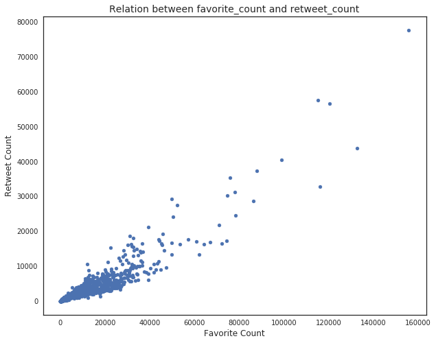

```python
# scatterplot showing relation between retweet_count and favorite_count
twitter_data_enhanced.plot(x='favorite_count',y='retweet_count',kind='scatter',s=25, figsize=(10,8));
plt.title('Relation between favorite_count and retweet_count',fontsize=14);
plt.ylabel('Retweet Count',fontsize=12);
plt.xlabel('Favorite Count',fontsize=12);
```

> The scatterplot reflects a positive correlation between retweet count and favorite count. There is a clear indication that if a tweet is getting more likes then the probability of more retweets increases.

### Insight 5: Relationship between retweet count, favorite count and ratings( standardized )

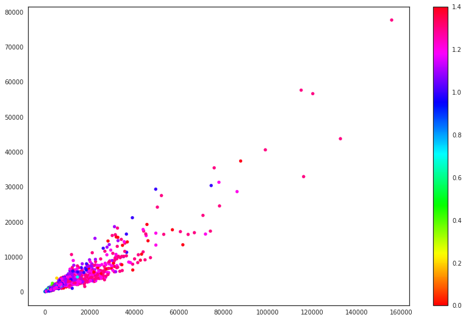

```python
#drop rows with outliers as it will lead to incorrect analysis of the relationship between variables
df3=twitter_data_enhanced.drop([975,1593],axis=0)
#plot the relation between standardized rating, retweet count and favorite count using scatter plot
plt.figure(figsize = (14, 9))
x = df3.favorite_count
y = df3.retweet_count
z = df3.rating_standardized
plt.scatter(x,y, c=z, s=25, cmap=cm.hsv)
cbar= plt.colorbar()
plt.show()
```

> In the scatter plot above we can see the positive correlation between retweet count and favorite count. We also observe that higher retweet counts and favorite counts have higher ratings as the dots are mostly pink with specs of blue and red in areas under higher retweet count and favorite count. Thus we can say that a tweet with higher rating is more likely to get more number of likes and retweets.

### Insight 6: Which tweet has the highest rating, highest retweet count and highest favorite count

```python
#find the tweet_ids which have the maximum ratings
df3[df3.rating_standardized == df3.rating_standardized.max()]['tweet_id']
```

```
3       825535076884762624
33      794205286408003585
47      685547936038666240
53      854120357044912130
58      822462944365645825
63      807621403335917568
83      742465774154047488
156     881536004380872706
244     828381636999917570
248     819006400881917954
249     819004803107983360
267     821407182352777218
279     755206590534418437
284     890240255349198849
298     832273440279240704
```

[output cut: 22 more lines]

```python
#find the tweet which has the maximum retweet count
twitter_data_enhanced[twitter_data_enhanced.retweet_count == twitter_data_enhanced.retweet_count.max()]['tweet_id']
```

```
293    744234799360020481
Name: tweet_id, dtype: int64
```

```python
#find th tweet which has the maximum favorite count
twitter_data_enhanced[twitter_data_enhanced.favorite_count == twitter_data_enhanced.favorite_count.max()] ['tweet_id']
```

```
293    744234799360020481
Name: tweet_id, dtype: int64
```

> We can see that the tweet with highest retweet count is the same as the tweet which has the highest favorite count. This shows that retweet count and favorite count have a strong correlation. Also, tweets with more retweets are going to be seen by more people and hence the chances of getting more likes increases. The tweets with higher ratings generally have higher retweets and likes but the correlation is not so strong.